# Discrete Density-Dependent Patterns in a Continuous Survival and Emigration Process

Eric Buhle

2022-12-09

## Preamble

Consider a population undergoing simultaneous, continuous-time processes of mortality and emigration. A fixed initial cohort of residents *R*<sub>0</sub> will decline toward zero, with the balance of losses depending on the details of the functions governing survival and dispersal over time. Further suppose that both mortality and emigration are potentially density-dependent, and that we would like to infer the structure and functional forms of such density dependence. The data available to do this consist of an estimate of *R*<sub>0</sub> and estimates of cumulative migration Δ*M*<sub>*t*</sub> over discrete time steps (e.g., days) *t* - 1 to *t*. Let’s assume for the sake of illustration that we observe both of these state variables without error, and that the underlying dynamics are deterministic.

To make things concrete, suppose survival is density-dependent, while emigration is density-independent but subject to periodic forcing. For stream-rearing salmonids, this represents a minimal set of assumptions that can serve as a sort of null model against which to measure any empirical patterns we might observe in real data.

## A Toy Model

We can model these population dynamics as a simple system of ODEs using the **deSolve** package in R. First we need to define the system as a function. Let’s take the resident population dynamics *dR*/*dt* to be logistic, with a negative intrinsic growth rate *r* since there is no reproduction. Over a finite time step Δ*t* the logistic integrates to give a Beverton-Holt function, and we can more easily parameterize by the maximum (density-independent) survival *s*<sub>0</sub> and the asymptote *R*<sub>max</sub>, which we then solve for the logistic parameters *r* and *K*.

```r
library(deSolve)

survive_migrate <- function(t, x, parms)
{
  with(as.list(c(x, parms)), {
    r <- log(s0)
    K <- Rmax*(s0 - 1)/s0
    dRdt <- r*R*(1 - R/K) - dMdt(t, R, m, tau)
    dMdt <- dMdt(t, R, m, tau)

    return(list(c(dRdt, dMdt)))
  })
}
```

We’ll model the time-dependent per capita migration rate (1/*R*)*dM*/*dt* as a periodic function with baseline rate *m*, period *τ*, and a linear increase with time *t* so that the last migration pulses are reasonably large even though few residents remain.

```r
dMdt <- function(t, R, m, tau)
{
  R*m*t*exp(sin(2*pi*t/tau))
}
```

Now we can simulate the dynamics by numerically solving the ODEs. We’ll set the forcing period so that there are four migration pulses over the “migration season” of *T* = 100 time steps, which is normalized to length 1.

```r
times <- seq(0, 1, length = 100)
parms <- c(s0 = 0.5, Rmax = 100, m = 2, tau = max(times)/3.75)
RMt <- ode(func = survive_migrate, parms = parms, y = c(R = 100, M = 0), times = times)
RMt <- data.frame(RMt)
```

Here are the population dynamics. The lower panel shows the change in cumulative emigration per time step – i.e., what we would observe in discrete daily sampling. The vertical lines between migration pulses define the partition we will use when looking for density dependence at each stage.

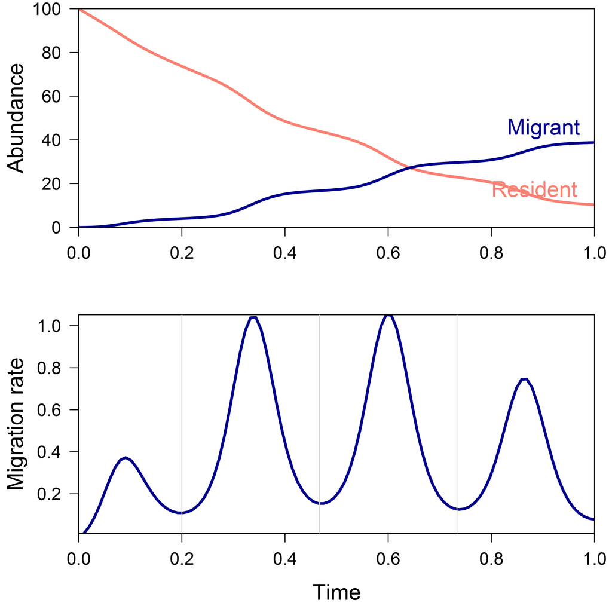

## A Range of Simulations

To do that we first need to repeat the simulation over a range of initial densities *R*<sub>0</sub>. This time we’ll only record cumulative total emigrants Δ*M*<sub>*t*</sub> over each of the four discrete intervals or stages indicated above.

We’ll also compute the additive log ratios of these stage-specific totals, using the final stage as the reference category. The conceptual motivation is that we can reparameterize the sequential stage-specific density-dependent relationships (all based on initial cohort size, as *R*(*t*) is not directly observed) into a single overall density-dependent function and the proportions of migrants in each stage, which may or may not show residual density dependence.

```r
R0 <- seq(1, parms["Rmax"]*10, length = 100)
R0Mt <- do.call(rbind, lapply(R0, function(R) {
  out <- ode(func = survive_migrate, parms = parms, y = c(R = R, M = 0),
             times = c(0, seq(0.75*parms["tau"], max(times), parms["tau"])))
  dplyr::mutate(data.frame(R0 = R, out), dM = c(NA, diff(M)), alrM = log(dM / tail(dM,1)))
}))
```

A plot of the final total of emigrants and surviving residents against initial cohort size clearly shows the effect of density-dependent resident survival. In fact, if the baseline emigration rate *m* were zero, this curve would simply be the Beverton-Holt.

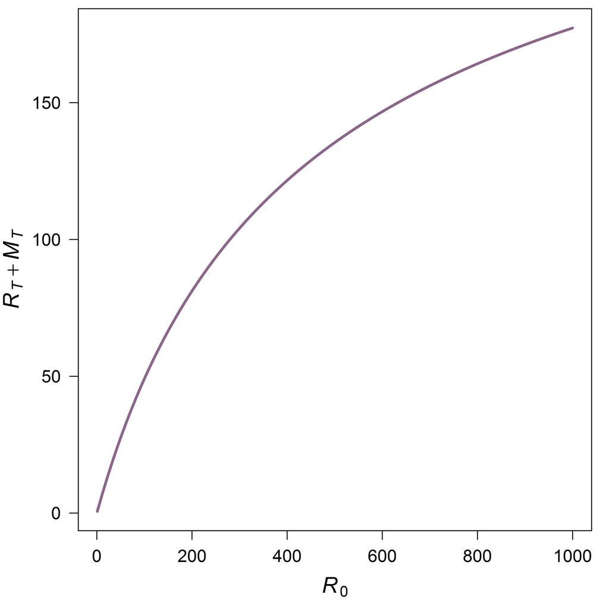

Now let’s examine density dependence in each stage-specific migrant pulse from time *t* - 1 to *t*, with respect to initial cohort size.

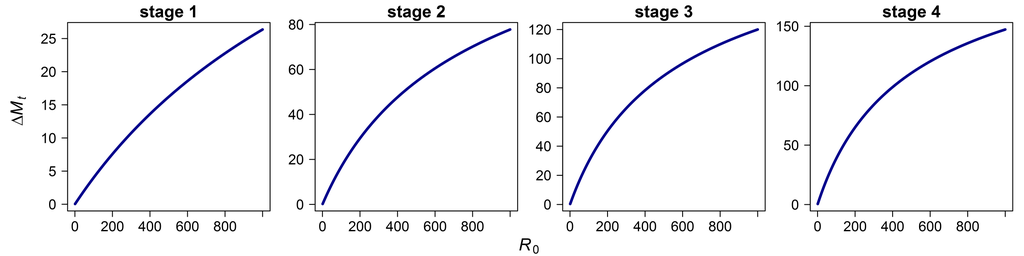

Again we see the signature of density-dependent resident survival, even though we can only observe migrants and the instantaneous migration rate itself is density-independent. Interestingly, the apparent strength of density dependence increases steadily throughout the migration season because the migrants are drawn from a pool of residents that has experienced more and more density-dependent mortality.

Perhaps counterintuitively, the same patterns emerge when we transform the compositional data (proportion of migrants in each pulse, conditional on total migration) from the simplex to additive log-ratio space. Because the loss of residents through density-dependent mortality increases with initial cohort size and disproportionately reduces the later migration pulses, the ratio of any earlier pulse to the final one increases with *R*<sub>0</sub>, but in a saturating way. We could choose different reference classes and get different but mathematically equivalent patterns; the underlying residual density dependence would remain.

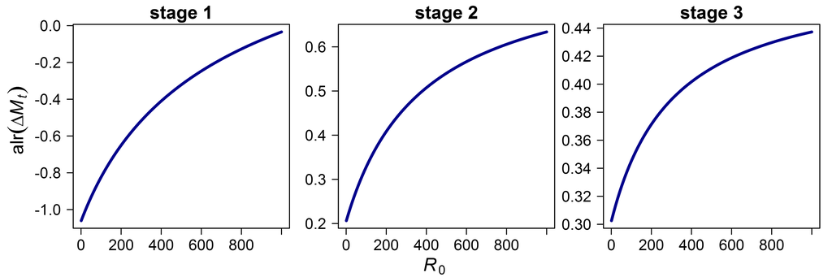

## Alternative Assumptions

```r
dMdt <- function(t, R, m, tau)
{
  R^2*m*t*exp(sin(2*pi*t/tau))
}
```

Again we simulate the dynamics, this time with the baseline migration rate *m* reduced to account for the extra factor of *R*.

```r
times <- seq(0, 1, length = 100)
parms <- c(s0 = 0.5, Rmax = 100, m = 0.05, tau = max(times)/3.75)
RMt <- ode(func = survive_migrate, parms = parms, y = c(R = 100, M = 0), times = times)
RMt <- data.frame(RMt)
```

The solution doesn’t look drastically different from the density-independent migration case, but the magnitude of the later pulses declines faster due to not only the dwindling population of residents but also the reduced emigration pressure from conspecific density.

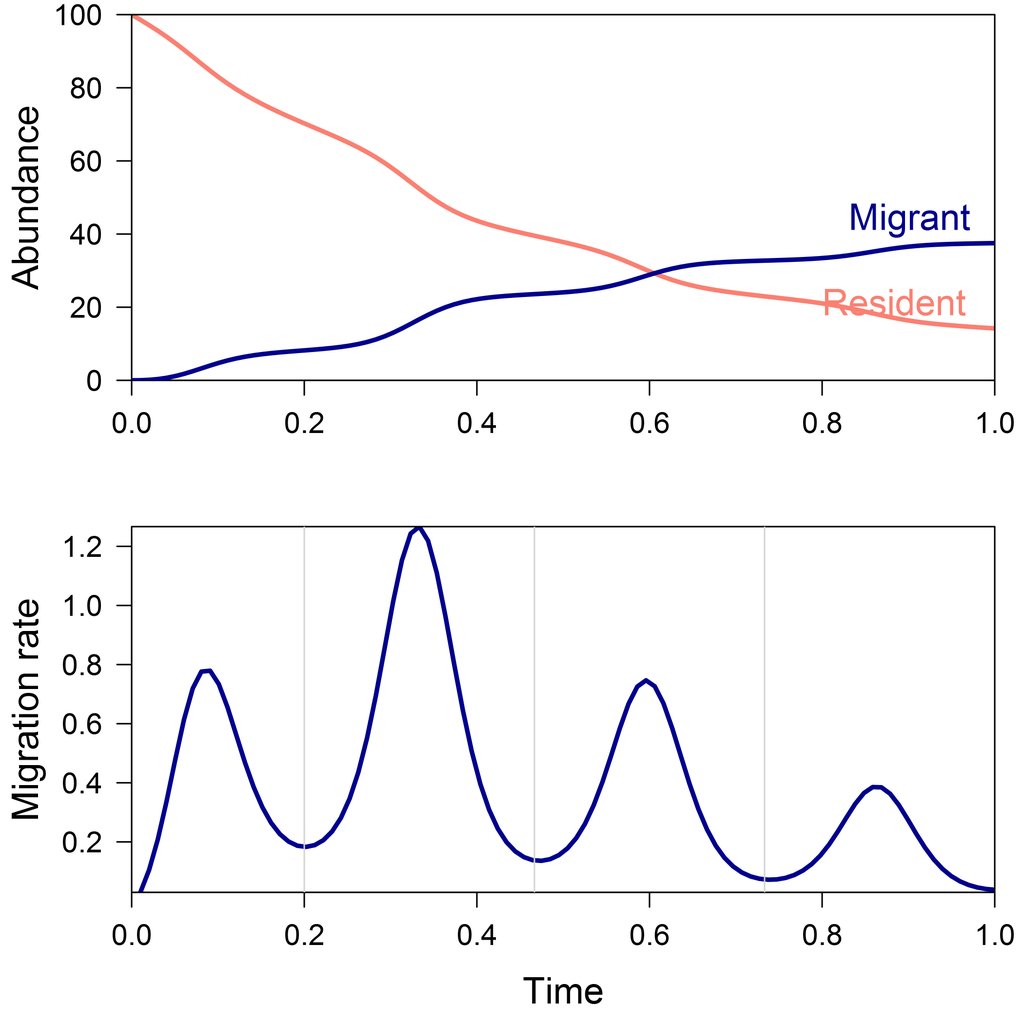

The patterns of apparent density dependence in total emigrants from each pulse or stage, on the other hand, are completely different. Rather than compensation they seem to show depensation, with just a hint of an inflection point appearing in the later stages. “Depensation” is a misnomer in this case, however, as we are only observing migrants (whose subsequent fate, density-dependent or not, is unknown). In fact, these patterns reflect the balance between direct density-dependent losses from the resident pool that occur through emigration vs. mortality. The precise balance and resulting functional forms depend on the parameters, but initial exploration failed to find parameter values producing “realistic” dynamics, for which the relationships are convex in the early stages but strongly concave in the later ones.

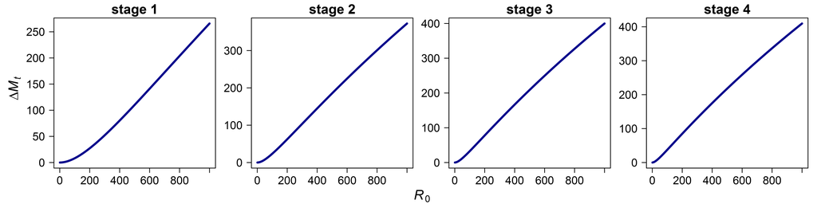

Interestingly, the relationships in log-ratio space have the same concave form as in the density-independent migration case. By standardizing the migration pulses relative to one another, we recapture the diminishing returns later in the season as density increases – doubly so now that the migration pressure on the remaining residents weakens as their cohort declines.

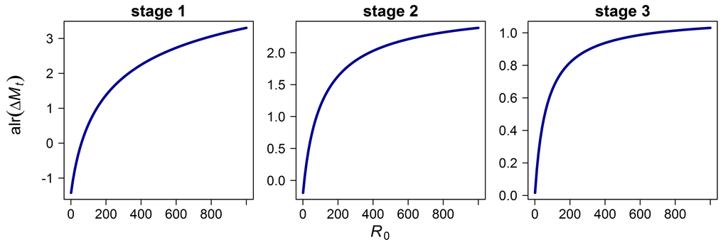

## Summary

This simple thought experiment is helpful in formulating a null hypothesis or baseline expectation of what we might see in empirical data on daily emigration from a system simultaneously undergoing mortality. One immediate conclusion is that density dependence of the entire cohort with respect to initial abundance manifests in migrant counts, even when the per capita migration rate itself and the timing and magnitude of its peaks are density-independent. Density-dependent emigration also manifests, and appears to produce very distinct patterns, at least for the model structure and parameter space considered here.

It is also notable that the apparent strength of compensation, at least with respect to initial cohort size *R*<sub>0</sub>, increases across successive migration pulses or stages regardless of density dependence in migration. It seems somewhat unlikely, based on limited parameter exploration, that this shift would be strong enough to convert an accelerating density-dependent relationship in stage 1 to a saturating one by stage 4. This suggests that such a pattern would require another explanation – for example, that the instantaneous migration rate becomes less strongly density-dependent over the course of the season, either gradually or abruptly.

Unfortunately, the log-ratio transformation does not appear to remove the compensatory density dependence, suggesting we cannot cleanly reparameterize from the abundance of each migrant pulse to the total abundance and relative frequency in each successive stage. However, the persistence (and enhancement) of concave functional forms in the log-ratio plots, even when the corresponding plots of abundance are convex, suggests a possible diagnostic to distinguish between the two hypotheses about emigration.